# Advanced Visualizations Lecture 03

# 4.0.0 Annotating your plots

After preparing your visualization you may consider adding extra annotations. These are *usually* layers that don’t affect the aesthetics or data of your visualization but depending on how you add them and the package you are using this isn’t strictly true. For the most part, however, let’s consider your annotations as separate from your plot.

We haven’t yet dabbled in annotations in our lectures but we’ll introduce them now and look deeply at how these work as well as some more advanced annotation packages.

## 4.1.0 `annotate()` plots with shapes, text, and arrows.

Sometimes you need to add some additional text, or shapes to your graph that aren’t necessarily a part of the data itself. In other words you would like to *annotate* your plot. To accomplish this you can use the `annotate()` function which will essentially add geoms to your plot. While these annotations can affect the axis limits of your plot if it is required to show your annotation(s), they won’t affect the legends nor be treated as actual data - just an overlay to your plot.

The `annotate()` geom has the following parameters:

| Parameter | Description |
| --- | --- |
| geom | Can be any number of possible values including “text”, “rect”, “segment”, “curve”, etc. |
| xmin, xmax, ymin, ymax, xend, yend | Positioning aesthetics where at least one of these must be defined. |
| … | Other aesthetics arguments that can be passed along like `color = "red"` |
| na.rm | If `FALSE`, missing values are removed with a warning otherwise they are silently removed |

### 4.1.1 Add a rectangle annotation to your plot

When naming your `geom` parameter, you can essentially use whatever `geom_*()` are available within ggplot. For instance, we’ll annotate using a `geom_rect()` by setting `geom = "rect"`. Some of the `geom_rect()` parameters include:

- `xmin` and `xmax`: the left/right points of the rectangle
- `ymin` and `ymax`: the lower/upper bounds of the rectangle
- `fill` and `alpha`: which are the same usual parameters we see in our other geoms.

Let’s switch back to our lineplot and add some annotations to it! We’ll start with a couple of rectangles to cover the 2022-23 and 2024-25 seasons. Below you’ll find a handy chart to determine these values.

| Season | First Week (end) | Last Week (end) |
| --- | --- | --- |
| 2022-2023 | 2022-09-01 | 2023-08-26 |
| 2023-2024 | 2023-09-03 | 2024-06-08 |
| 2024-2025 | 2024-08-31 | 2025-08-23 |
| 2025-2026 | 2025-08-30 | 2026-02-21 |

How would you go about determining these values?

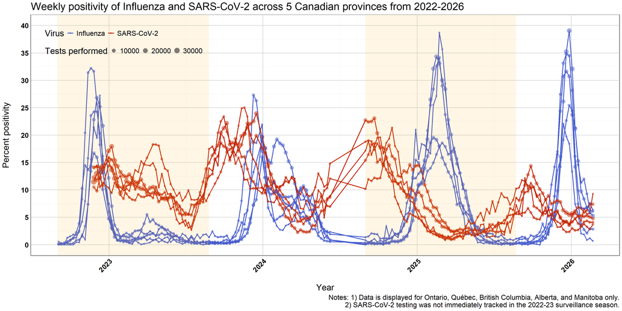

```r
# 4.1.1 annotate our line plots

respLine.plot +
  # Use a colour-blind friendly palette
  scale_colour_viridis_d(option = "turbo", begin = 0.1, end = 0.9) +

  ### 4.1.1 Add rectangles to show different seasons
  # 2022-2023
  annotate(geom="rect", xmin=as.Date("2022-09-01"), xmax=as.Date("2023-08-26"),
           ymin=-Inf, ymax=Inf, fill="orange", alpha=0.1) +

  # 2024-2025
  annotate(geom="rect", xmin=as.Date("2024-08-31"), xmax=as.Date("2025-08-23"),
           ymin=-Inf, ymax=Inf, fill="orange", alpha=0.1)
```